# Diversity in a Globalized World

Lecture 2: Globalization, Populism, and Democratic Erosion

Bogdan G. Popescu

bgpopescu@tec.mx

Tecnológico de Monterrey

## Where Monday left off

- The shock landed on **particular towns**, not on the country
- Ten years later the jobs were gone and the people were still there
- Autor, Dorn and Hanson followed those places. Then they followed the **votes**

So today’s question is: **what did that do to their politics?**

## The same places, on a map

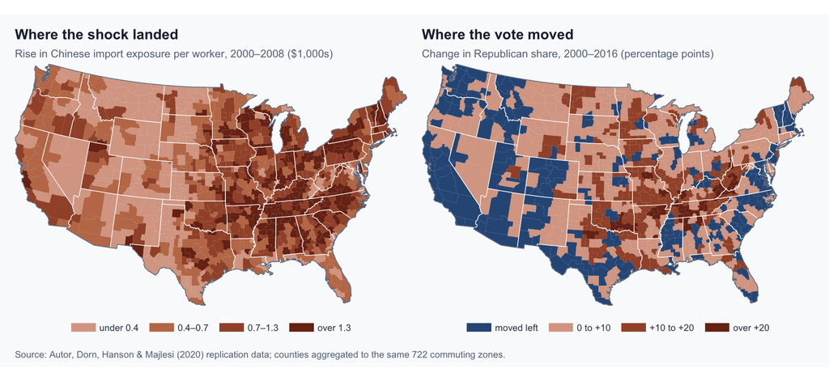

Figure 1

Monday’s 722 commuting zones, twice over: the shock on the left, the vote on the right. Where does the dark in one panel **not** line up with the dark in the other?

## The same places, and how they voted

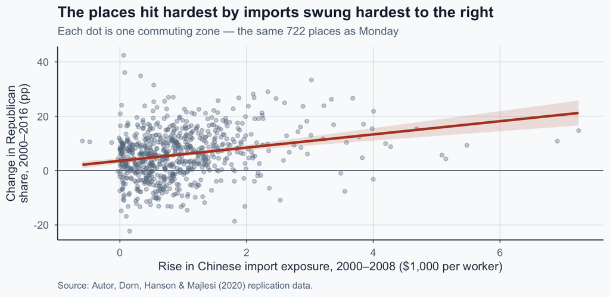

Figure 2

## What that picture shows

- Sort the 722 places into four groups by exposure
- Least exposed: **+4** points to the Republican candidate
- Most exposed: **+10** points — more than twice as much
- Same unit as Monday, same measure. Only the **outcome** changed

This plot is descriptive. The paper isolates the Chinese shock and controls for what each place already looked like — we are not doing that today.

## Exercise 1 — What else could explain it?

The places that lost the most factory jobs swung hardest to the right. The obvious story: **people who lost work voted against the party in power.**

**In pairs: name two other things that could produce exactly the same picture.**

Then take one of them: what would you look at to tell it apart from the job-loss story?

## Possible Answers

- **It was already going** — these places were declining before China arrived
- **Immigration** — the same towns received migrants: about neighbours, not jobs
- **Who lives there** — older, whiter, less urban, less educated; each predicts the swing on its own
- **The candidate** — 2016 was Trump, not an average Republican
- **The campaigns** — both parties poured effort into exactly these states

Every one of these produces **the same scatterplot**.

## Telling them apart

What you want is a comparison the two stories **disagree** about:

- Same trade shock, **no** immigration — does the swing survive?
- Same demographics, **no** shock — does the swing disappear?
- The swing measured **before 2016** — is it still there without Trump on the ballot?

# I. Two Different Problems

## Two Phenomena, Often Confused

- **Competitive authoritarianism** (Levitsky & Way, 2010): a *regime type*
  - Elections are real but the playing field is tilted
  - These regimes were *never fully democratic*
- **Democratic backsliding**: a *process*
  - Consolidated democracies erode incrementally
  - No clean rupture — legal, step-by-step decline
- Conflating these is the most common error in casual commentary

## Regime Type vs. Process

```
flowchart TD
    A["Democracy"] -->|"Democratic backsliding<br/>(PROCESS)"| B["Eroding democracy"]
    B -.->|"Further deterioration<br/>may produce"| C["Competitive authoritarianism<br/>(REGIME TYPE)"]
    D["Other historical paths<br/>without prior democracy"] --> C
    style A fill:#e8f5e9,stroke:#4a7c6f,color:#163829
    style B fill:#fff3e0,stroke:#b7943a,color:#513800
    style C fill:#fbe9e7,stroke:#b44527,color:#662719
    style D fill:#f1f5f9,stroke:#64748b,color:#334155
```

## How democracies die now

Today’s reading, Bermeo (2016), makes the case:

- Backsliding is **incremental**, not sudden
- The usual form is **executive aggrandizement** — elected leaders weakening the checks on themselves
- Each step is defensible; the cumulative effect is not
- **This lecture:** what *logic* makes those steps possible?

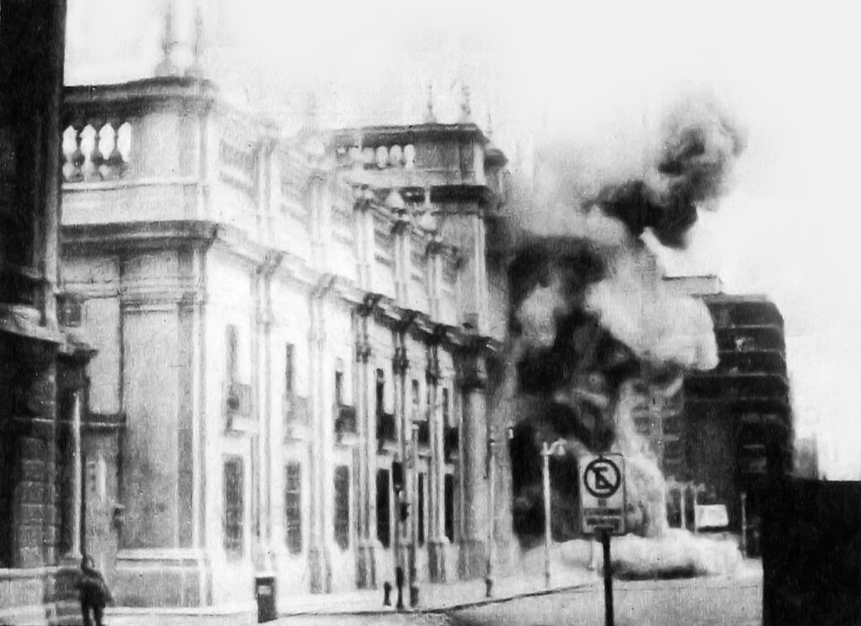

Bombing of La Moneda, Santiago, 1973 — how democracies *used* to die. Source: Biblioteca del Congreso Nacional de Chile (CC BY 3.0 CL).

## Cases at a Glance

- **Competitive authoritarianism:** Russia under Putin, Singapore, Cambodia
  - Elections exist but were *never* free and fair
- **Democratic backsliding:** Hungary, Poland, Turkey, Venezuela
  - Democracies that eroded *after* consolidation
- **Promissory coups:** Thailand (2014), Egypt (2013), Myanmar (2021)
  - Military seizure with “restoration” rhetoric
- Most dangerous today: **backsliding** — hardest to detect

## Which is it?

The three labels, in plain terms:

- **Competitive authoritarianism** — elections are real, the field was never level
- **Democratic backsliding** — a real democracy, eroding step by step
- **Promissory coup** — seized by force, with a promise to hand it back

## Which one fits each case?

1. A country has held free, competitive elections for thirty years. Its government now rewrites the electoral law so the opposition can no longer win a majority.
2. **The very same law** — but in this country, the opposition has never once been allowed to win.
3. The army removes an elected president, suspends the constitution, and promises elections within the year.

## The answers

- **1 — democratic backsliding.** A working democracy is dismantling itself
- **2 — competitive authoritarianism.** Nothing is being lost; it was never there
- **3 — promissory coup.** The rhetoric of restoration, the machinery of seizure

Cases 1 and 2 are **the same law**. All that changed was where the country started — and that is the distinction commentary gets wrong most often.

## The Question for This Lecture

- Not asking: *why do regimes hold fake elections?*
- We are asking: **Why do some democracies dismantle themselves?**
- What political logic makes this possible?
- **One influential answer: populism**

# II. What Is Populism?

## Not a Policy — A Logic

**Mudde & Kaltwasser (2017):** Populism is a *thin ideology*.

- Society divided into two homogeneous, antagonistic groups
- **“The pure people”** vs. **“the corrupt elite”**
- Politics should express the *volonté générale* of the people
- A claim about **legitimate authority**, not policy
- Compatible with left *and* right

## Left and Right Populism

- **Left populism:** people = dispossessed; elite = oligarchy
  - Chávez, Morales, Podemos, AMLO
- **Right populism:** people = native majority; elite = cosmopolitans
  - Orbán, Trump, Le Pen, Salvini
- Same *structure*, different *content*
- Thin ideology attaches to thicker host ideologies

## Populism vs. Pluralism

The real contrast is not left/right but **populism vs. pluralism**:

Source: Adapted from Mudde & Kaltwasser (2017).

|  | **Populism** | **Pluralism** |
| --- | --- | --- |
| **Society** | One people, one will | Multiple legitimate interests |
| **Opposition** | Enemies of the people | Legitimate competitors |
| **Institutions** | Obstacles if they constrain | Necessary checks on power |
| **Compromise** | Betrayal | Essential to governance |
| **Mandate** | Absolute — elections settle everything | Partial — rights constrain majorities |

## Why Populism Is Not Just “Angry Voters”

- Economic grievance ≠ populism
- You can be economically frustrated and still accept pluralism
- Populism = *political logic* attaching to many grievances
- What matters here: a logic that can put it **in tension with pluralist constraints**

## Why the courts become the enemy

Three steps. Each one sounds reasonable on its own.

1. **The people have one will** — the election revealed it
2. **I speak for the people** — that is what winning means
3. So anyone who blocks me is **blocking the people**

Nothing about the court has changed. What changed is what it is **called**.

Careful: this is a **tendency**, not a definition. If we define populism as “rejecting checks,” then “populism erodes checks” is true by construction — and therefore untestable. The claim only has content if populism is defined independently, as Mudde does.

## The same institution, renamed

| What it was | What it is called |
| --- | --- |
| An independent court | “Activist judges blocking the people’s will” |
| A free press | “Fake news serving elite interests” |
| An electoral commission | “A deep state undermining democracy” |

Now removing the check is the **democratic** act — and defending it is the elite one. That inversion is the whole danger.

## Populist Logic → Erosion Feedback Cycle

```
%%{init: {'theme': 'base', 'themeVariables': {'fontSize': '18px', 'primaryColor': '#4a7c6f', 'primaryTextColor': '#1e293b', 'lineColor': '#334155', 'primaryBorderColor': '#334155'}, 'flowchart': {'useMaxWidth': true, 'nodeSpacing': 40, 'rankSpacing': 55}}}%%
flowchart LR
    A["<b>Electoral victory</b><br/>claimed as<br/>the people's mandate"] --> B["<b>Institutions framed</b><br/>as elite obstacles"]
    B --> C["<b>Constraints weakened</b><br/>courts packed, media<br/>pressured, rules changed"]
    C --> D["<b>Opposition disadvantaged</b><br/>playing field tilted"]
    D --> E["<b>Next victory larger</b><br/>mandate 'confirmed'"]
    E --> A
    style A fill:#e8f5e9,stroke:#4a7c6f,stroke-width:2px
    style B fill:#fff3e0,stroke:#b7943a,stroke-width:2px
    style C fill:#fbe9e7,stroke:#b44527,stroke-width:2px
    style D fill:#fbe9e7,stroke:#b44527,stroke-width:2px
    style E fill:#e8f5e9,stroke:#4a7c6f,stroke-width:2px
```

## The Populist Redefinition of Institutions

- **Pluralism:** checks protect everyone, including minorities
- **Populism:** checks protect *elites* from *the people*
- Same institutions, opposite interpretations
- Legitimacy *only* from popular mandate
- Judicial independence, press freedom → suspect
- “I am *finally making democracy real*”
- Populism and erosion: **logically connected**

# III. Why Now?

## The Populist Wave

- Populist surge across democracies in the 2010s
- Not one region, ideology, or grievance
- Europe, Latin America, Asia, the US
- **Why did this happen when it did?**
- Four explanations compete; none has won

[figure not shown]

European Parliament hemicycle, Strasbourg. Source: Diliff, Wikimedia Commons (CC BY-SA 3.0).

## Populist Vote Share in Europe

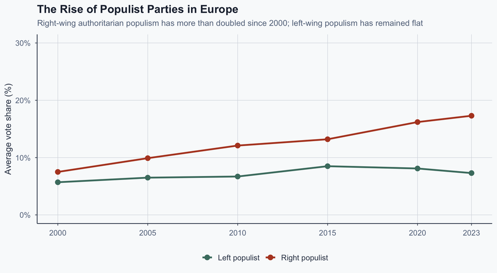

Figure 3: Mean populist party vote share across European democracies. Source: Timbro Authoritarian Populism Index (2024).

## Four Competing Explanations

Compare these with the list you made in Exercise 1.

Source: Framework draws on Inglehart & Norris (2016), Mudde & Kaltwasser (2017).

| Explanation | Mechanism | Key prediction |
| --- | --- | --- |
| **Economic insecurity** | Globalization losers, deindustrialization, 2008 crisis | Populist support concentrated among economically displaced |
| **Cultural backlash** | Status threat from immigration, value change, secularism | Strongest among older, culturally traditional voters |
| **Elite failure** | Party convergence, cartelization, no meaningful choice | Strongest where mainstream parties most similar |
| **Media ecology** | Algorithmic amplification, epistemic fragmentation | Correlates with social media penetration |

## ▶ Media Ecology — Inside the Feed

[video not shown]

**DEBATE: Should governments force social media platforms to expose users to political views they disagree with?**

**FOR:** Breaking echo chambers protects democracy.

**AGAINST:** Forced exposure may make polarization worse.

## A Provisional Thesis

- Dominant debate: **economic vs. cultural** — but either/or misleads
- There is credible evidence for **both** channels
- Their relative weight appears to **vary by setting**
- How much, and where, is **not settled**
- Next two slides: one careful study on each side

## Trying to Disentangle: Two Key Studies

- **Colantone & Stanig (2018):** import shock → populist vote
  - **Economic channel confirmed** in periphery
- **Mutz (2018):** status threat predicts Trump support (panel data)
  - **Cultural channel confirmed** in wealthy democracies
- Not contradictory — *different contexts*

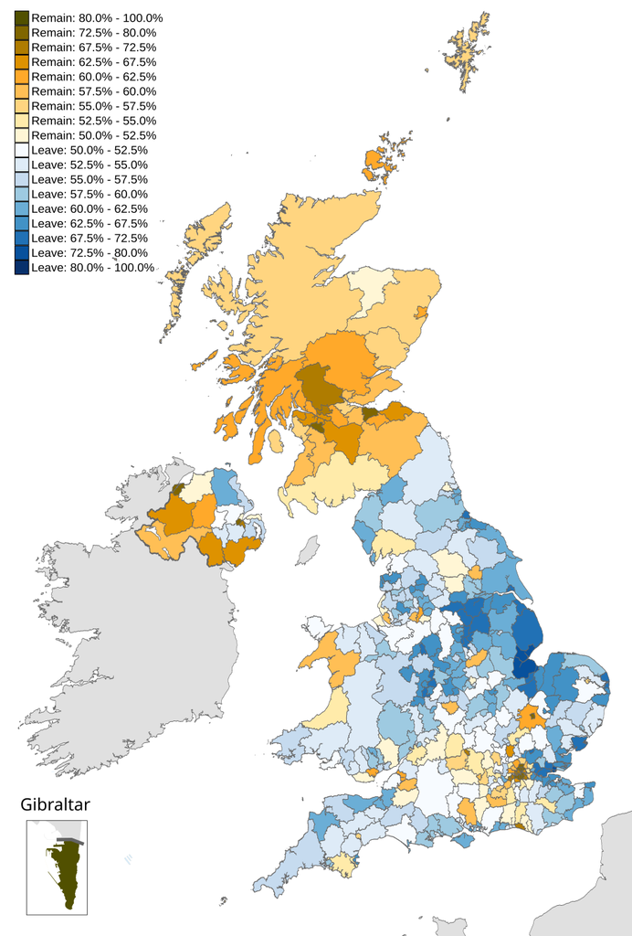

## The Identification Problem

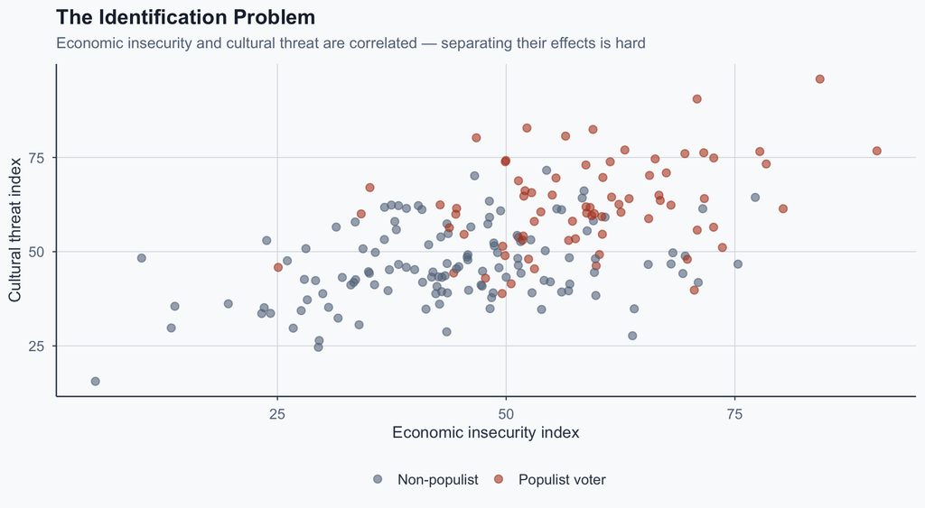

Figure 4: Conceptual illustration: economic and cultural explanations predict overlapping populations.

## Why the Cause Matters for Policy

- If economic → redistribute and the populist wave recedes
- If cultural → redistribution alone will not suffice
- **Both channels are real**; neither explains every case
- Trade shocks do visible work in deindustrialised regions
- Status threat shows up strongly in survey panels
- **No single policy lever** — that *is* the finding
- **Wrong cause → wrong policy**

# IV. Populism and Institutional Erosion

## Ginsburg & Huq: Constitutional Retrogression

**Ginsburg & Huq (2018):** three pillars of liberal democracy under attack:

1. **Competitive elections** — gerrymandering, media capture, electoral rule changes
2. **Liberal rights** — press freedom curtailed, civil society squeezed, minority rights eroded
3. **Rule of law** — court packing, prosecutorial independence eliminated, constitutional amendments
- Retrogression = systematic degradation across all three
- Each step is individually *small* and *legal*

## Three Pillars Under Attack

```
%%{init: {'theme': 'base', 'themeVariables': {'fontSize': '16px', 'primaryColor': '#4a7c6f', 'primaryTextColor': '#1e293b', 'lineColor': '#334155', 'primaryBorderColor': '#334155'}, 'flowchart': {'useMaxWidth': true, 'nodeSpacing': 16, 'rankSpacing': 60}}}%%
flowchart LR
    A["<b>Liberal Democracy</b>"] --> B["<b>Competitive Elections</b>"]
    A --> C["<b>Liberal Rights</b>"]
    A --> D["<b>Rule of Law</b>"]
    B --> B1["Gerrymandering"]
    B --> B2["Media capture"]
    B --> B3["Electoral rule changes"]
    C --> C1["Press freedom curtailed"]
    C --> C2["Civil society squeezed"]
    C --> C3["Minority rights eroded"]
    D --> D1["Court packing"]
    D --> D2["Prosecutors politicized"]
    D --> D3["Constitutional rewrites"]
    style A fill:#e8f5e9,stroke:#4a7c6f,stroke-width:3px
    style B fill:#fff3e0,stroke:#b7943a,stroke-width:2px
    style C fill:#fff3e0,stroke:#b7943a,stroke-width:2px
    style D fill:#fff3e0,stroke:#b7943a,stroke-width:2px
    style B1 fill:#fbe9e7,stroke:#b44527,stroke-width:1px
    style B2 fill:#fbe9e7,stroke:#b44527,stroke-width:1px
    style B3 fill:#fbe9e7,stroke:#b44527,stroke-width:1px
    style C1 fill:#fbe9e7,stroke:#b44527,stroke-width:1px
    style C2 fill:#fbe9e7,stroke:#b44527,stroke-width:1px
    style C3 fill:#fbe9e7,stroke:#b44527,stroke-width:1px
    style D1 fill:#fbe9e7,stroke:#b44527,stroke-width:1px
    style D2 fill:#fbe9e7,stroke:#b44527,stroke-width:1px
    style D3 fill:#fbe9e7,stroke:#b44527,stroke-width:1px
```

## Applying the Framework: Hungary

Bermeo’s incremental steps, in the Ginsburg & Huq frame:

- **Elections:** rules redrawn (2014); media captured
- **Rights:** NGO law (2017); CEU forced out
- **Rule of law:** court packed (2012–13); new constitution
- All three pillars degraded — textbook retrogression

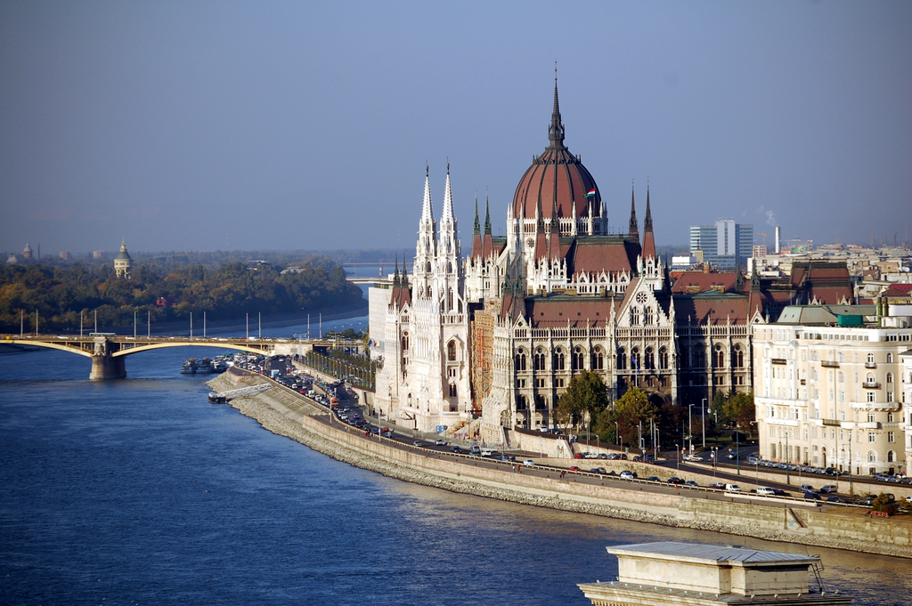

Hungarian Parliament, Budapest. Source: Wikimedia Commons (CC BY-SA 3.0).

## V-Dem Liberal Democracy Index

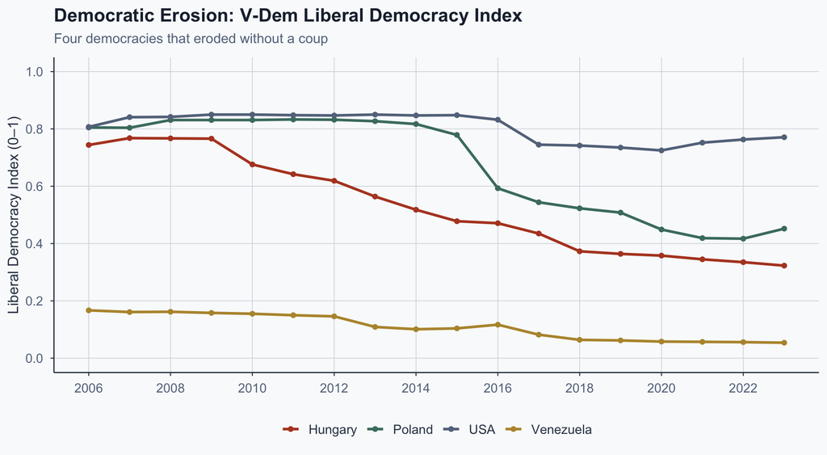

Figure 5: V-Dem Liberal Democracy Index (v2x_libdem, 0–1). Source: V-Dem Institute, Dataset v14.

## Case: Venezuela Under Chávez

- 1998: Chávez elected in a real democracy
- 1999–2004: New constitution, court packed (20 → 32)
- Media pressured; oil-funded patronage → dominance
- By 2010: competitive authoritarianism

[figure not shown]

Capitolio Federal, Caracas — seat of the National Assembly. Source: Wikimedia Commons (CC BY-SA 3.0).

## Venezuela: The Oil-Fueled Variant

- Resource rents → no tax-based accountability
- Patronage replaced party competition
- Opposition boycotted 2005 elections → legitimacy gift
- Under Maduro: full authoritarian consolidation
- Same logic as Hungary + resource-curse dynamics
- Populist erosion not confined to one ideology

## Case: Mexico Under AMLO

- 2018: AMLO wins with 53%; Morena supermajority 2024
- **Elections:** INE budget cut, board politicized
- **Rights:** military in civilian roles; press pressured
- **Rule of law:** 2024 reform → judges elected by popular vote, **June 2025**
- INAI (transparency body) left non-functional
- Framed as “returning power to the people”

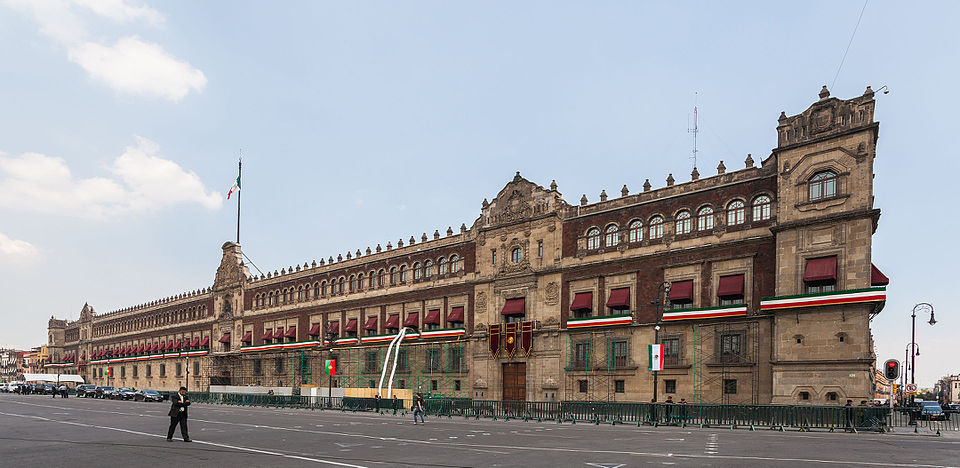

National Palace, Mexico City — seat of the executive. Source: Diego Delso, Wikimedia Commons (CC BY-SA 3.0).

## Mexico, after the first judicial election

- **1 June 2025:** voters elected roughly **2,600** judges and magistrates
- Among them, **all nine** Supreme Court justices
- Turnout: about **13%**
- Every Supreme Court seat went to a candidate aligned with the governing party
- The remaining federal judges are elected in **2027**

We are no longer asking what the reform *will* do. We can ask what it **did**.

Source: INE turnout estimate (12.6–13.3%) and results reported June 2025.

## Comparing the Cases

|  | **Hungary** | **Venezuela** | **Mexico** |
| --- | --- | --- | --- |
| **Populism of the** | right | left | left |
| **How the courts fell** | constitution rewritten | bench packed, paid for with oil | judges put to a vote |
| **How long it took** | about 2 years | about 10 years | 2024 law, 2025 election |
| **Where it stands** | elections, but unfair | no longer a democracy | too early to say |

**The difference that matters:** the first two *packed* their courts. Mexico *elected* its own — independence redefined as accountability.

Not a first: Bolivia has elected its high-court magistrates since 2011. Mexico’s novelty is the scale — the entire federal judiciary. Sources: Ginsburg & Huq (2018), Levitsky & Way (2010), V-Dem.

## Exercise 2

### Applying the Framework (7 min)

Using Ginsburg & Huq’s three pillars, evaluate Mexico under AMLO/Morena:

1. **Competitive elections:** What changed? What was threatened?
2. **Liberal rights:** Which rights or freedoms were affected?
3. **Rule of law:** What happened to judicial independence?

**Is this retrogression, democratic deepening, or something else?**

The first judicial election has already happened. **What can you observe now that you could not have observed in 2024 — and what would you still need?**

# V. Cause or Symptom?

## Cause or Symptom? Why It Matters

- Populism: **cause** or **symptom** of erosion?
- **Epiphenomenal:** fix delivery → populism recedes
- **Causal:** populist logic is itself a mechanism
- If symptom → policy reform suffices
- If causal → constitutional design matters directly
- Different prescriptions; getting it wrong is costly

## The Evidence — and What Sharpens It

- Hungary: institutions worked *before* Fidesz → erosion was not inevitable
- Venezuela: institutions were already weak *before* Chávez → more symptom than cause
- Two cases chosen after the fact do not settle it
- **Poland adds a third kind of evidence** — next slide

## Poland: a reversal, not an experiment

- **2015–2023:** PiS packed the courts and captured public media
  - V-Dem liberal democracy: **0.78 → 0.42**
- **2023:** Tusk’s coalition wins; courts and media partly restored
- So erosion is **not** a one-way street — that much this case shows

## The Democratic Recession in Numbers

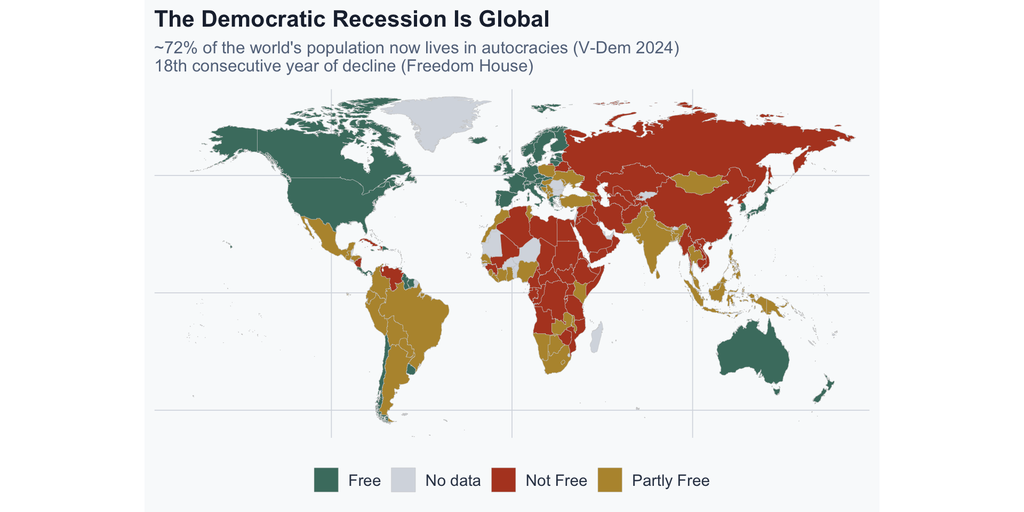

Figure 6: Approximate global freedom status. Source: Simplified classification based on Freedom House (2024).

## Conclusion

- Competitive authoritarianism ≠ democratic backsliding
- Populism = a thin ideology that can collide with pluralist checks
- Evidence for **both** the economic and the cultural channel; the balance varies
- Ginsburg & Huq: erosion attacks elections, rights, rule of law
- Poland shows erosion can be **reversed** — not why it reversed
- Mexico elects its judges: new in **scale**, not in kind (see Bolivia, 2011)

## References

- Autor, D.H., Dorn, D., Hanson, G.H. & Majlesi, K. (2020). Importing political polarization? The electoral consequences of rising trade exposure. *American Economic Review*, 110(10), 3139–3183.
- Bermeo, N. (2016). On democratic backsliding. *Journal of Democracy*, 27(1), 5–19.
- Bail, C.A., Argyle, L.P., Brown, T.W., Bumpus, J.P., Chen, H., et al. (2018). Exposure to opposing views on social media can increase political polarization. *PNAS*, 115(37), 9216–9221.
- Colantone, I. & Stanig, P. (2018). The trade origins of economic nationalism: Import competition and voting behavior in Western Europe. *American Journal of Political Science*, 62(4), 936–953.
- Ginsburg, T. & Huq, A.Z. (2018). *How to Save a Constitutional Democracy*. Chicago: University of Chicago Press.
- Guess, A.M., Malhotra, N., Pan, J., Barberá, P., Allcott, H., et al. (2023). How do social media feed algorithms affect attitudes and behavior in an election campaign? *Science*, 381(6656), 398–404.
- Inglehart, R. & Norris, P. (2016). Trump, Brexit, and the rise of populism: Economic have-nots and cultural backlash. *HKS Working Paper* No. RWP16-026.
- Levitsky, S. & Way, L.A. (2010). *Competitive Authoritarianism: Hybrid Regimes After the Cold War*. Cambridge: Cambridge University Press.
- Mudde, C. & Kaltwasser, C.R. (2017). *Populism: A Very Short Introduction*. Oxford: Oxford University Press.
- Nyhan, B., Settle, J., Thorson, E., Wojcieszak, M., Barberá, P., et al. (2023). Like-minded sources on Facebook are prevalent but not polarizing. *Nature*, 620(7972), 137–144.
- Mutz, D.C. (2018). Status threat, not economic hardship, explains the 2016 presidential vote. *Proceedings of the National Academy of Sciences*, 115(19), E4330–E4339.